# Box-Jenkins — ARIMA

## El término d en el ARIMA (p,d,q) integrated

Veamos qué significa el d en la escritura ARIMA. Estimemos un modelo diferenciado

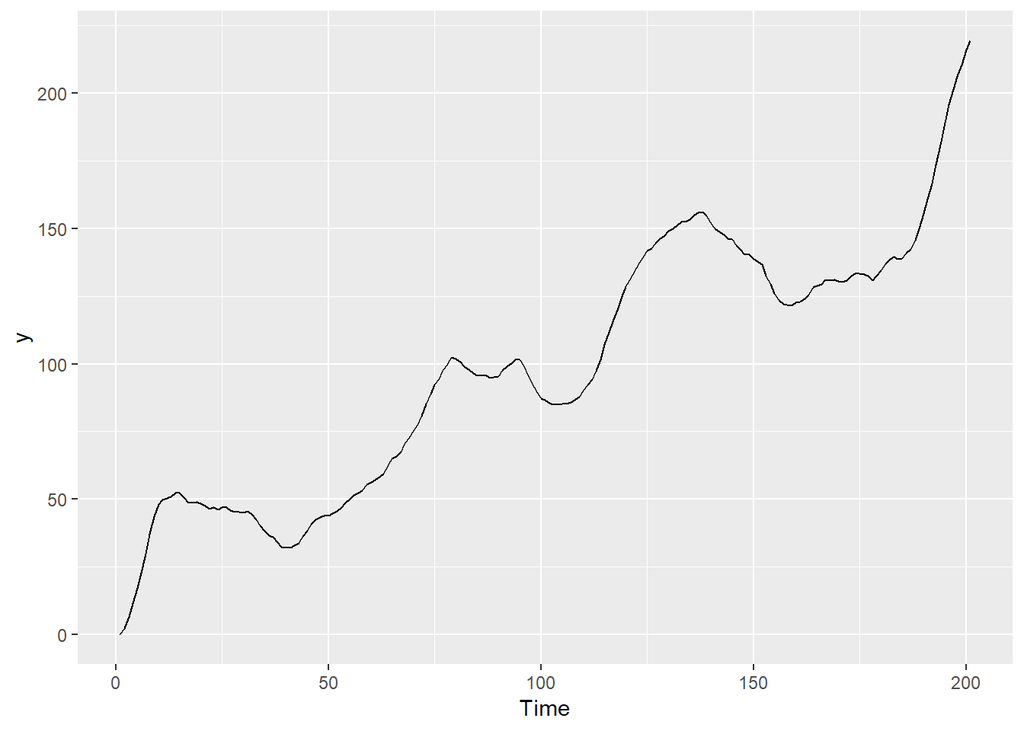

```r
y <- arima.sim(model = list(order = c(1, 1, 0), ar = .9), n = 200)

autoplot(y)
```

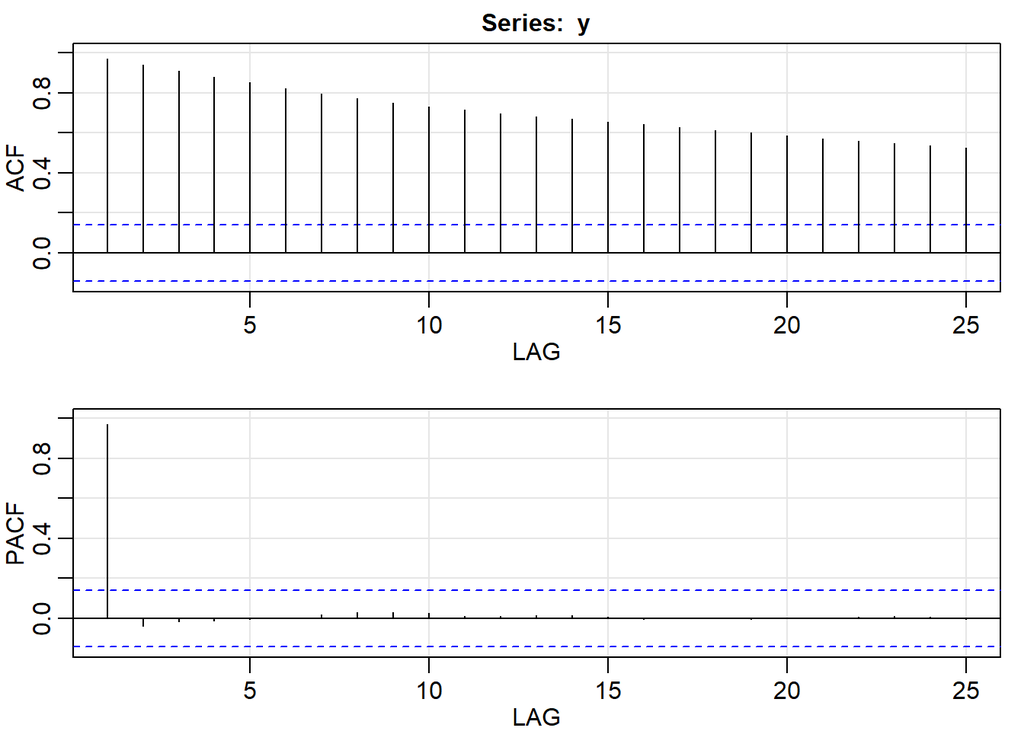

```
##        ACF  PACF
##  [1,] 0.97  0.97
##  [2,] 0.94 -0.04
##  [3,] 0.91 -0.02
##  [4,] 0.88 -0.01
##  [5,] 0.85 -0.01
##  [6,] 0.82  0.00
##  [7,] 0.80  0.02
##  [8,] 0.77  0.03
##  [9,] 0.75  0.03
## [10,] 0.73  0.03
## [11,] 0.71  0.01
## [12,] 0.70  0.01
## [13,] 0.68  0.02
## [14,] 0.67  0.01
## [15,] 0.65  0.01
## [16,] 0.64 -0.01
## [17,] 0.63  0.00
## [18,] 0.61  0.00
## [19,] 0.60  0.00
## [20,] 0.59  0.00
## [21,] 0.57  0.00
## [22,] 0.56  0.01
## [23,] 0.55  0.01
## [24,] 0.54  0.01
## [25,] 0.52 -0.01
```

```r
acf2(y)
```

Vemos que la serie no es estacionaria. Estacionaricemosla, y veamos de nuevo el correlograma.

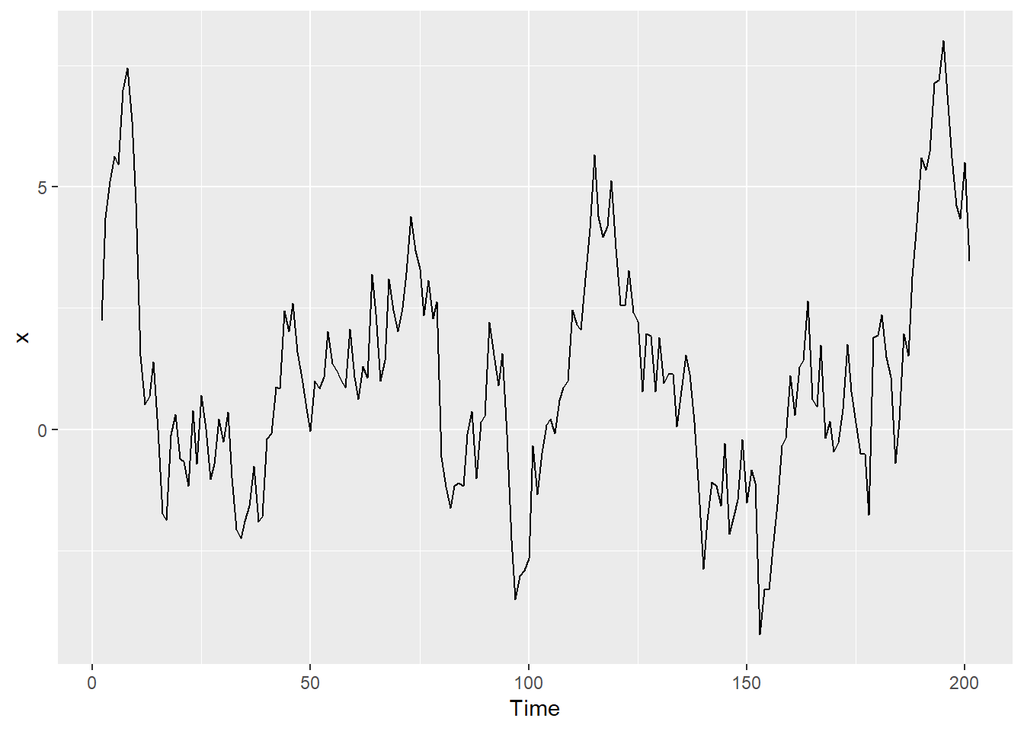

```r
x <- diff(y)

autoplot(x)
```

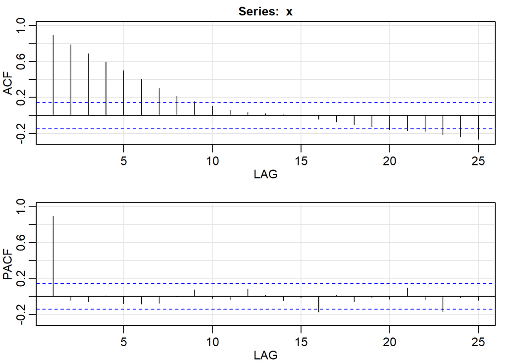

```
##         ACF  PACF
##  [1,]  0.89  0.89
##  [2,]  0.79 -0.04
##  [3,]  0.69 -0.06
##  [4,]  0.60  0.01
##  [5,]  0.50 -0.08
##  [6,]  0.40 -0.09
##  [7,]  0.30 -0.08
##  [8,]  0.21  0.00
##  [9,]  0.16  0.08
## [10,]  0.11 -0.02
## [11,]  0.06 -0.03
## [12,]  0.03  0.08
## [13,]  0.02  0.02
## [14,]  0.01 -0.05
## [15,]  0.00 -0.01
## [16,] -0.04 -0.17
## [17,] -0.07  0.01
## [18,] -0.10 -0.06
## [19,] -0.13 -0.01
## [20,] -0.16 -0.03
## [21,] -0.17  0.10
## [22,] -0.18 -0.03
## [23,] -0.21 -0.17
## [24,] -0.24 -0.01
## [25,] -0.27 -0.04
```

```r
acf2(x)
```

Finalmente, realicemos la estimación para la serie original, esto es, la serie no estacionaria. Esto es la base del proceso.

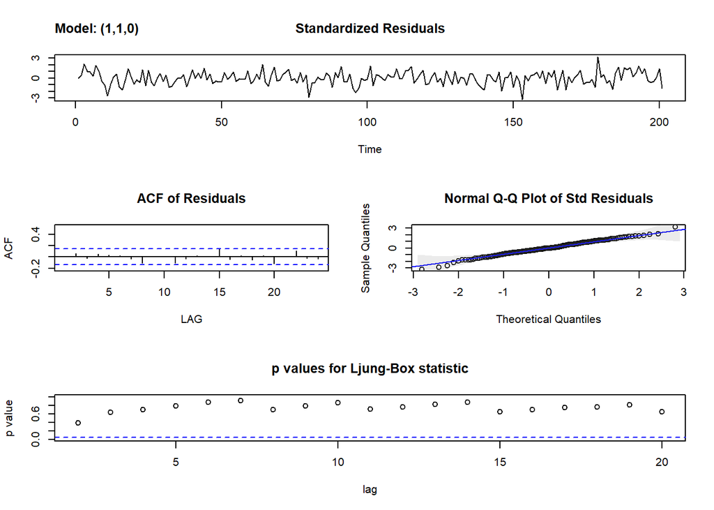

```
## $fit
##
## Call:
## stats::arima(x = xdata, order = c(p, d, q), seasonal = list(order = c(P, D,
##     Q), period = S), xreg = constant, optim.control = list(trace = trc, REPORT = 1,
##     reltol = tol))
##
## Coefficients:
##          ar1  constant
##       0.8954    1.2341
## s.e.  0.0306    0.6773
##
## sigma^2 estimated as 1.086:  log likelihood = -292.87,  aic = 591.74
##
## $degrees_of_freedom
## [1] 198
##
## $ttable
##          Estimate     SE t.value p.value
## ar1        0.8954 0.0306 29.2194    0.00
## constant   1.2341 0.6773  1.8220    0.07
##
## $AIC
## [1] 1.102636
##
## $AICc
## [1] 1.113192
##
## $BIC
## [1] 0.1355044
```

```r
sarima(y,p=1,d=1,q=0)
```

## Serie a10

Veamos la serie

```r
autoplot(a10) +  ylab("Ventas de medicamentos antidiabeticos en Australia") + xlab("Año")
```

[output not shown]

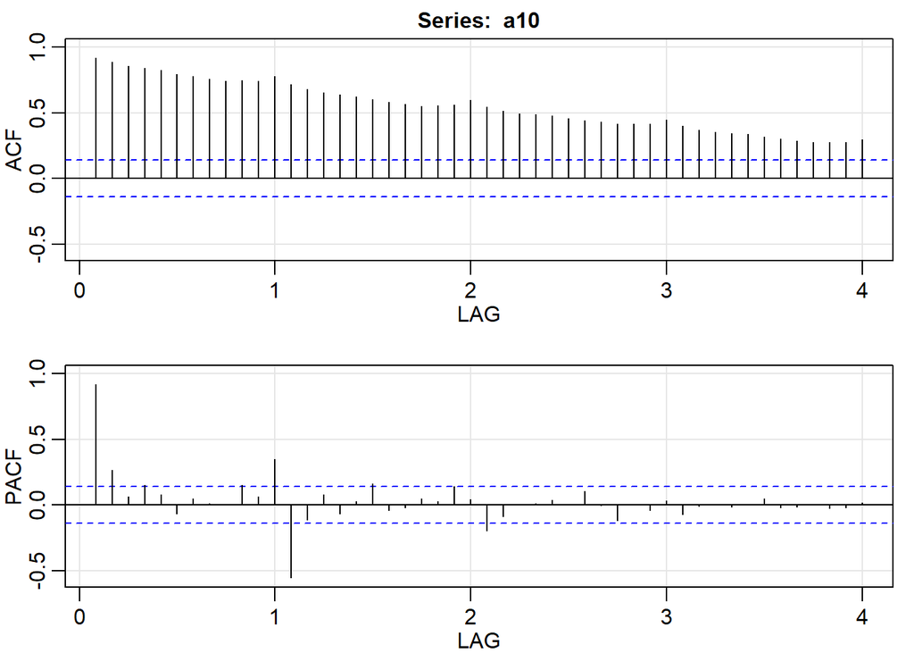

```
##        ACF  PACF
##  [1,] 0.92  0.92
##  [2,] 0.89  0.26
##  [3,] 0.85  0.07
##  [4,] 0.84  0.15
##  [5,] 0.83  0.08
##  [6,] 0.80 -0.06
##  [7,] 0.78  0.05
##  [8,] 0.76  0.01
##  [9,] 0.74  0.00
## [10,] 0.75  0.15
## [11,] 0.74  0.07
## [12,] 0.78  0.35
## [13,] 0.71 -0.55
## [14,] 0.68 -0.11
```

[output cut: 34 more lines]

```r
acf2(a10)
```

Estacionaricemos la serie

[figure not shown]

```r
diferencia_1 <- diff(log(a10),1)
diferencia_1_12 <-  diff(diferencia_1,lag=12)

autoplot(diferencia_1_12) +  ylab("") +  xlab("Rezagos") +
  ggtitle("Diferencia del valor del barril de petroleo")
```

Identifiquemos la serie

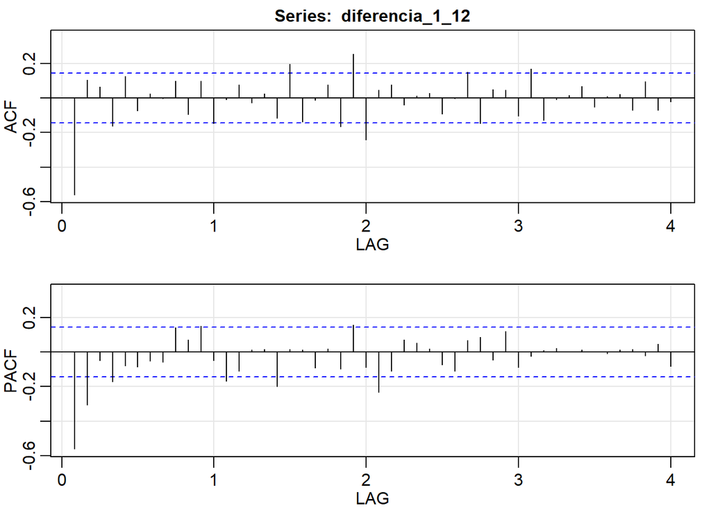

```
##         ACF  PACF
##  [1,] -0.56 -0.56
##  [2,]  0.11 -0.31
##  [3,]  0.06 -0.05
##  [4,] -0.16 -0.17
##  [5,]  0.13 -0.08
##  [6,] -0.07 -0.08
##  [7,]  0.02 -0.05
##  [8,]  0.00 -0.06
##  [9,]  0.10  0.14
## [10,] -0.10  0.07
## [11,]  0.10  0.15
## [12,] -0.15 -0.05
## [13,] -0.01 -0.17
## [14,]  0.08 -0.11
```

[output cut: 34 more lines]

```r
acf2(diferencia_1_12)
```

Estimemos la serie. ¿Qué podemos decir?

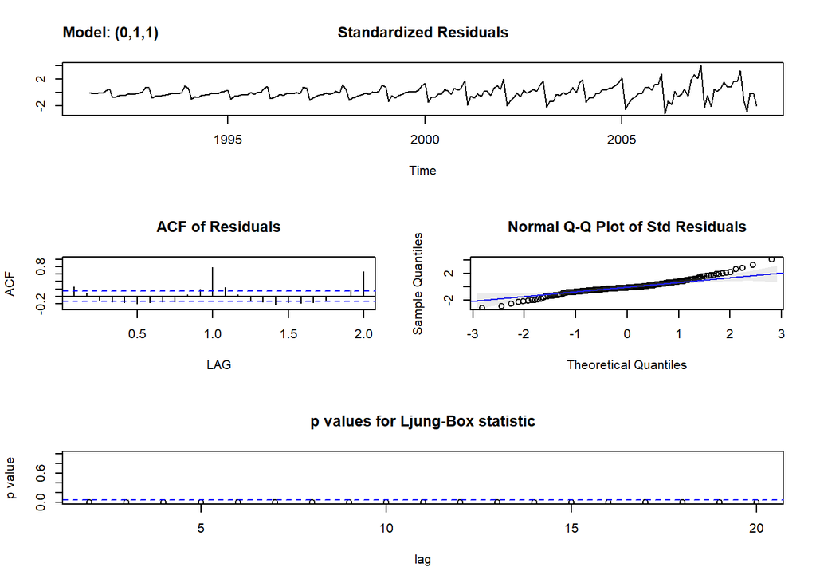

```
## $fit
##
## Call:
## stats::arima(x = xdata, order = c(p, d, q), seasonal = list(order = c(P, D,
##     Q), period = S), xreg = constant, optim.control = list(trace = trc, REPORT = 1,
##     reltol = tol))
##
## Coefficients:
##           ma1  constant
##       -0.8577    0.0971
## s.e.   0.0442    0.0203
##
## sigma^2 estimated as 3.884:  log likelihood = -426.44,  aic = 858.89
##
## $degrees_of_freedom
## [1] 201
##
## $ttable
##          Estimate     SE  t.value p.value
## ma1       -0.8577 0.0442 -19.4012       0
## constant   0.0971 0.0203   4.7770       0
##
## $AIC
## [1] 2.376587
##
## $AICc
## [1] 2.386979
##
## $BIC
## [1] 1.409117
```

```r
sarima(a10,0,1,1)
```

# Estimación del proceso ARIMA (p,d,q)(P,D,Q)s

## *unemp*

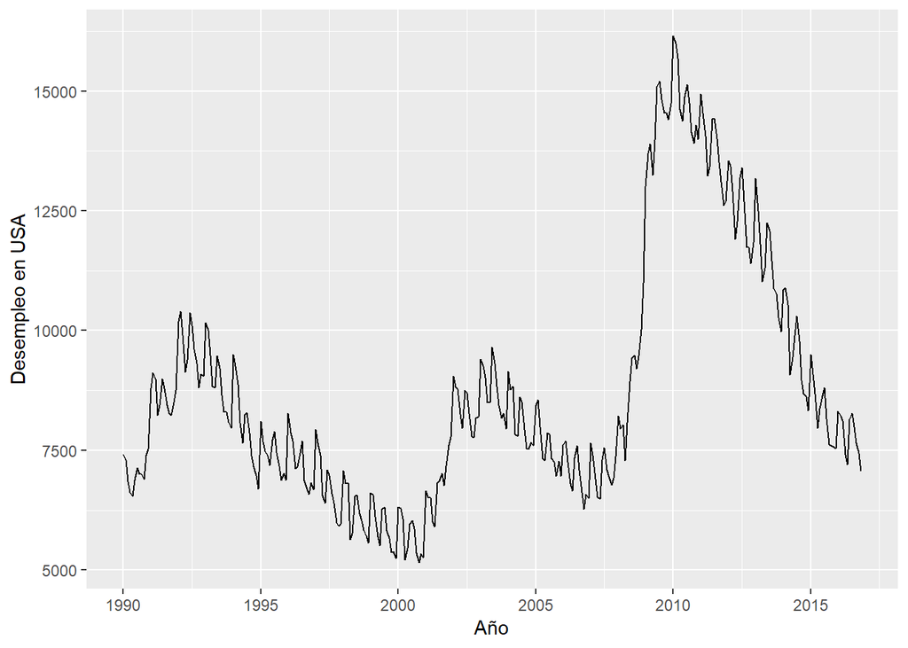

```r
autoplot((unemp)) +  ylab("Desempleo en USA") + xlab("Año")
```

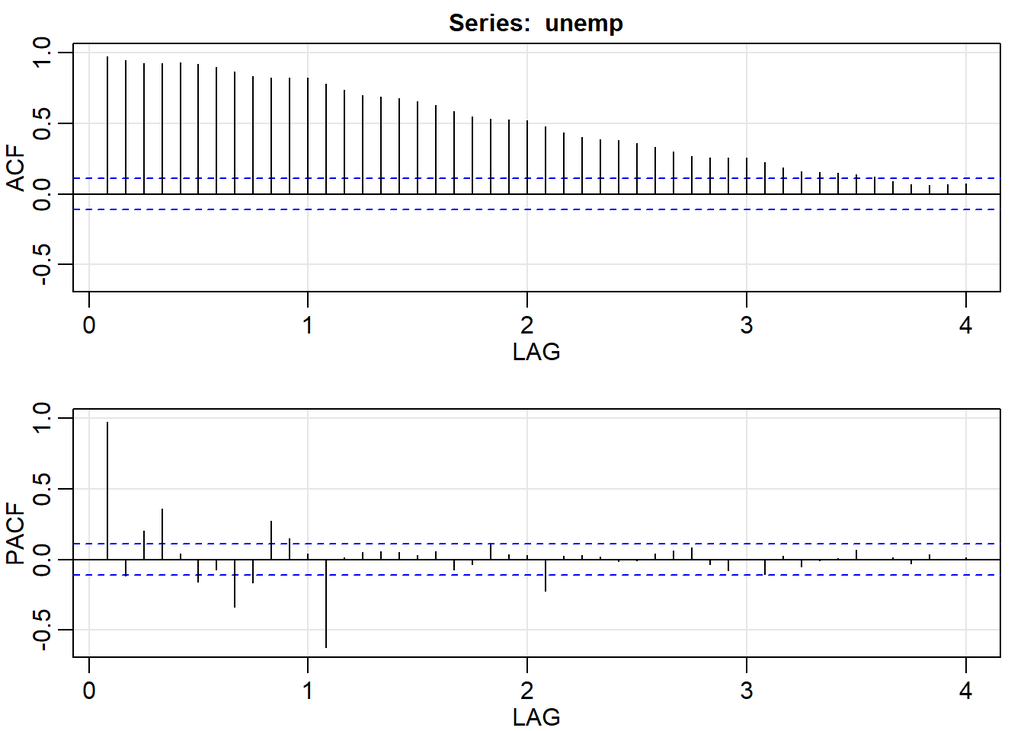

```
##        ACF  PACF
##  [1,] 0.98  0.98
##  [2,] 0.95 -0.11
##  [3,] 0.93  0.20
##  [4,] 0.93  0.36
##  [5,] 0.93  0.04
##  [6,] 0.92 -0.16
##  [7,] 0.90 -0.07
##  [8,] 0.86 -0.34
##  [9,] 0.83 -0.17
## [10,] 0.82  0.27
## [11,] 0.82  0.15
## [12,] 0.82  0.04
## [13,] 0.78 -0.62
## [14,] 0.74  0.02
```

[output cut: 34 more lines]

```r
acf2(unemp)
```

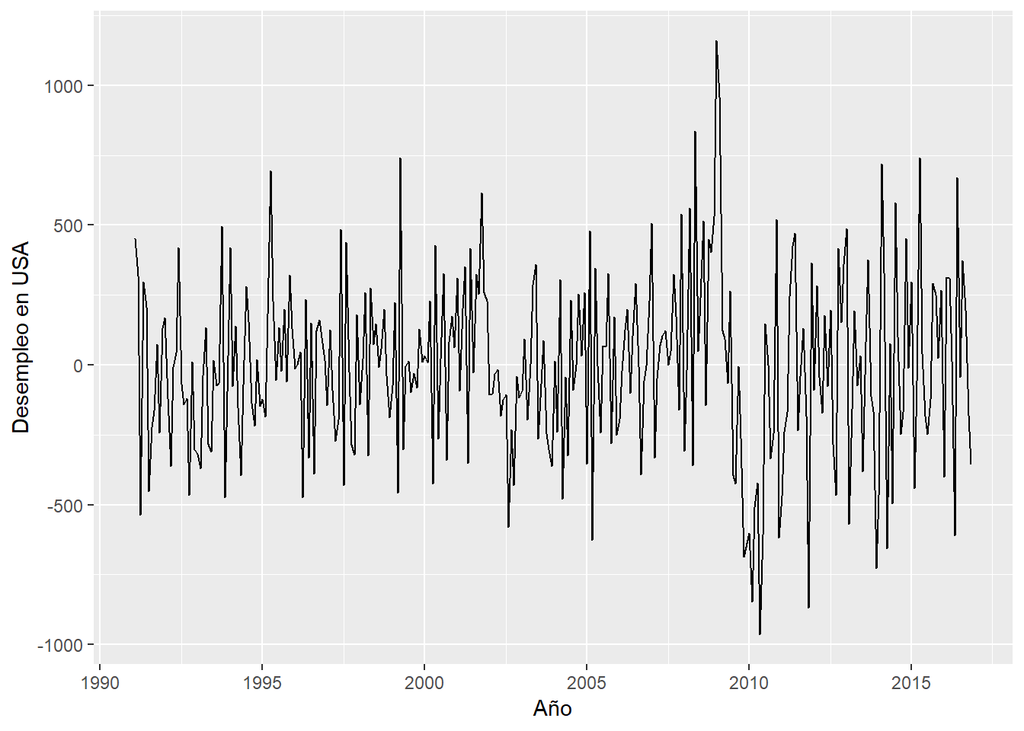

```r
d_unemp <- diff(unemp,1)
dd_unemp <- diff(d_unemp, lag = 12)

autoplot(dd_unemp) +  ylab("Desempleo en USA") + xlab("Año")
```

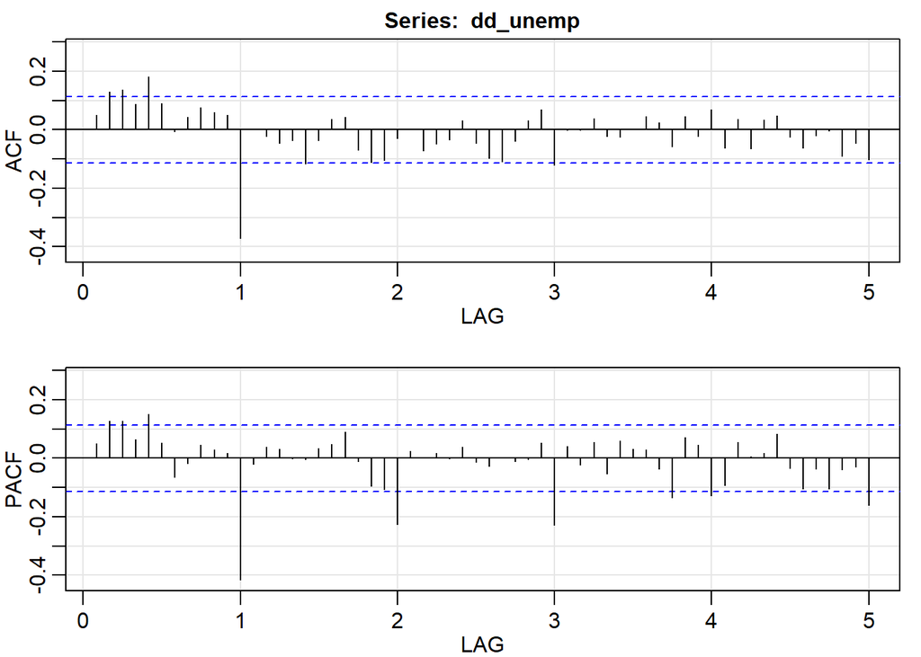

```
##         ACF  PACF
##  [1,]  0.05  0.05
##  [2,]  0.13  0.13
##  [3,]  0.14  0.13
##  [4,]  0.09  0.06
##  [5,]  0.18  0.15
##  [6,]  0.09  0.05
##  [7,] -0.01 -0.07
##  [8,]  0.04 -0.02
##  [9,]  0.08  0.05
## [10,]  0.06  0.03
## [11,]  0.05  0.02
## [12,] -0.37 -0.42
## [13,]  0.00 -0.02
## [14,] -0.02  0.04
```

[output cut: 46 more lines]

```r
acf2(dd_unemp,max.lag=60)
```

```r
mod1.1 <- Arima(unemp, order=c(2,1,0), seasonal=c(0,1,1))
summary(mod1.1)
```

```
## Series: unemp
## ARIMA(2,1,0)(0,1,1)[12]
##
## Coefficients:
##          ar1     ar2     sma1
##       0.0946  0.2081  -0.8512
## s.e.  0.0556  0.0556   0.0423
##
## sigma^2 estimated as 66176:  log likelihood=-2166.66
## AIC=4341.31   AICc=4341.44   BIC=4356.26
##
## Training set error measures:
##                     ME     RMSE      MAE        MPE     MAPE      MASE
## Training set -15.12281 250.7945 194.7522 -0.1669265 2.269629 0.1870934
##                     ACF1
## Training set -0.04149775
```

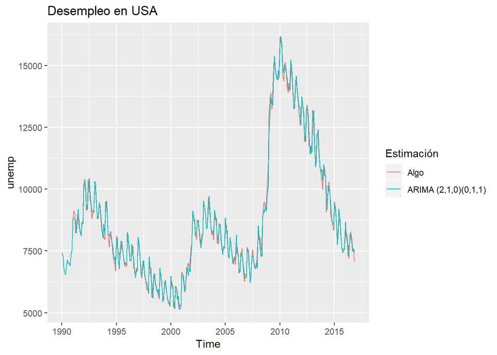

```r
#mod1 <-sarima(unemp,p=2,d=1,q=0,P=0,D=1,Q=1,S=12)


autoplot(unemp, series="Algo") +
  autolayer(fitted(mod1.1), series="ARIMA (2,1,0)(0,1,1)")+
  ggtitle("Desempleo en USA") +
  guides(colour=guide_legend(title="Estimación"))
```

## birth

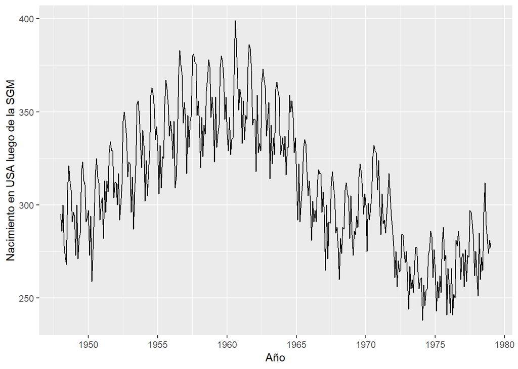

```r
autoplot(birth) +  ylab("Nacimiento en USA luego de la SGM") + xlab("Año")
```

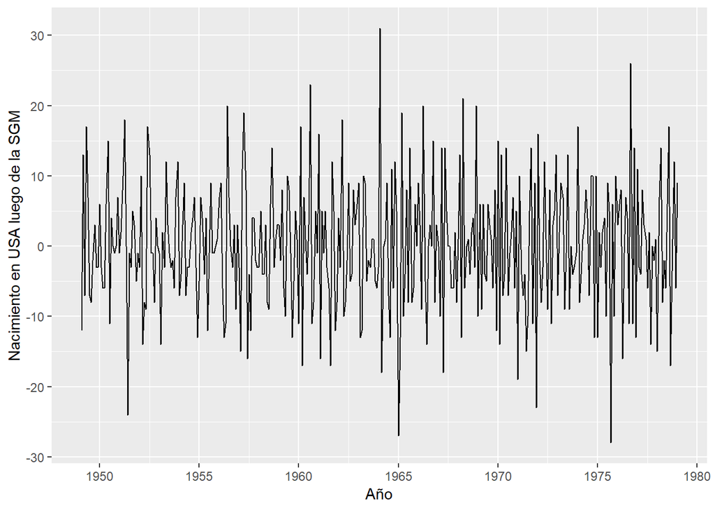

```r
d_birth <- diff(birth)
dd_birth <- diff(d_birth, lag = 12)

autoplot(dd_birth) +  ylab("Nacimiento en USA luego de la SGM") + xlab("Año")
```

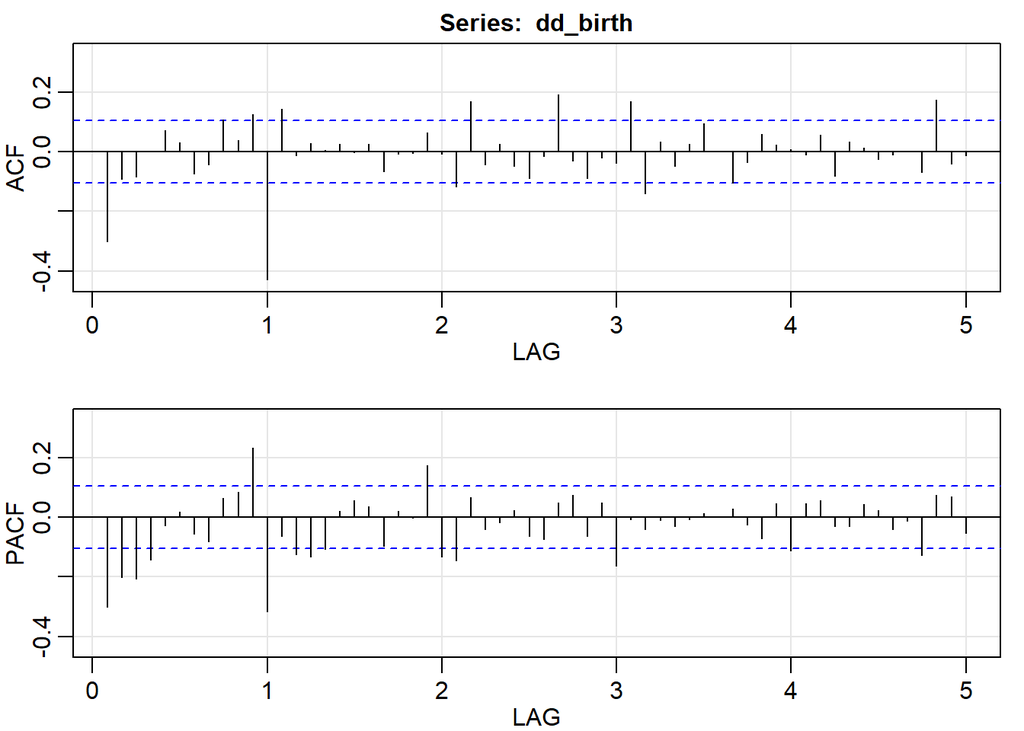

```
##         ACF  PACF
##  [1,] -0.30 -0.30
##  [2,] -0.09 -0.20
##  [3,] -0.09 -0.21
##  [4,]  0.00 -0.14
##  [5,]  0.07 -0.03
##  [6,]  0.03  0.02
##  [7,] -0.07 -0.06
##  [8,] -0.04 -0.08
##  [9,]  0.11  0.06
## [10,]  0.04  0.08
## [11,]  0.13  0.23
## [12,] -0.43 -0.32
## [13,]  0.14 -0.06
## [14,] -0.01 -0.13
```

[output cut: 46 more lines]

```r
acf2(dd_birth,max.lag=60)
```

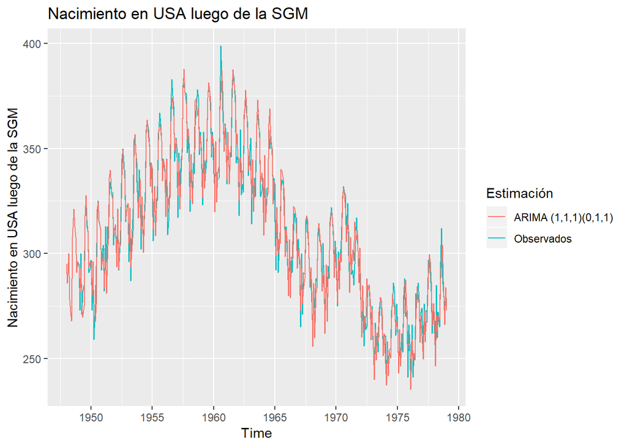

```r
mod1 <- Arima(birth, order=c(0,1,1), seasonal=c(0,1,1))
#mod1 <- sarima(birth,p=0,d=1,q=1,P=0,D=1,Q=1,S=12)

mod2 <- Arima(birth, order=c(1,1,1), seasonal=c(0,1,1))
#mod2 <- sarima(birth,p=1,d=1,q=1,P=0,D=1,Q=1,S=12)

autoplot(birth, series="Observados") + ylab("Nacimiento en USA luego de la SGM") +
  autolayer(fitted(mod2), series="ARIMA (1,1,1)(0,1,1)")+
  ggtitle("Nacimiento en USA luego de la SGM") +
  guides(colour=guide_legend(title="Estimación"))
```

## a10

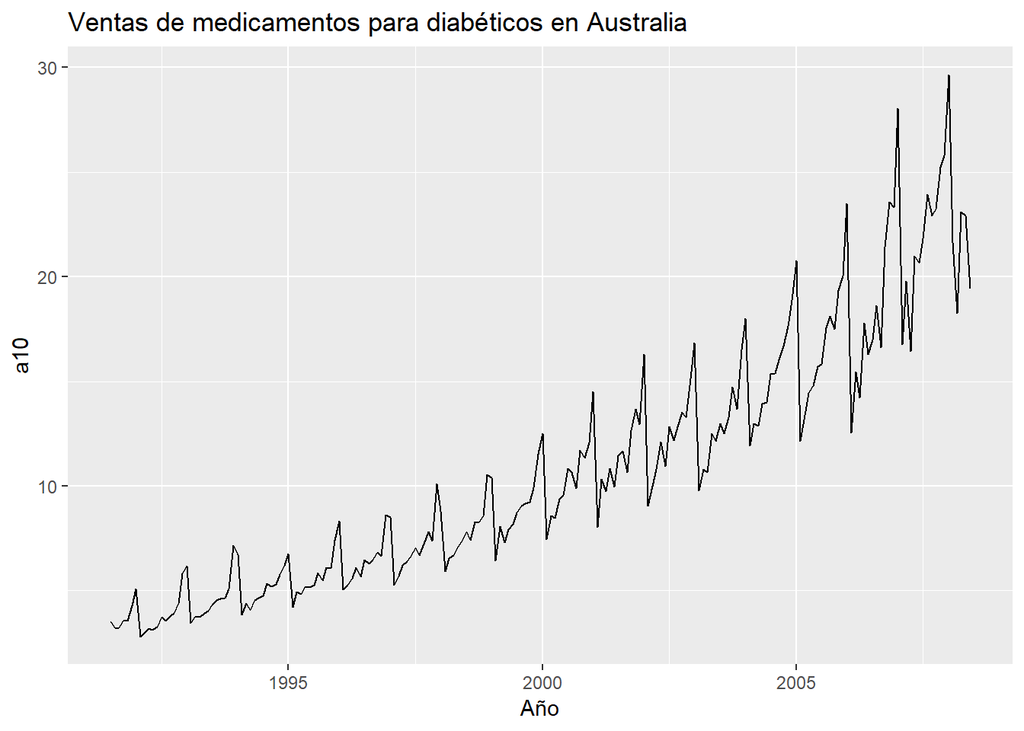

```r
autoplot(a10) +  ggtitle("Ventas de medicamentos para diabéticos en Australia")  + xlab("Año")
```

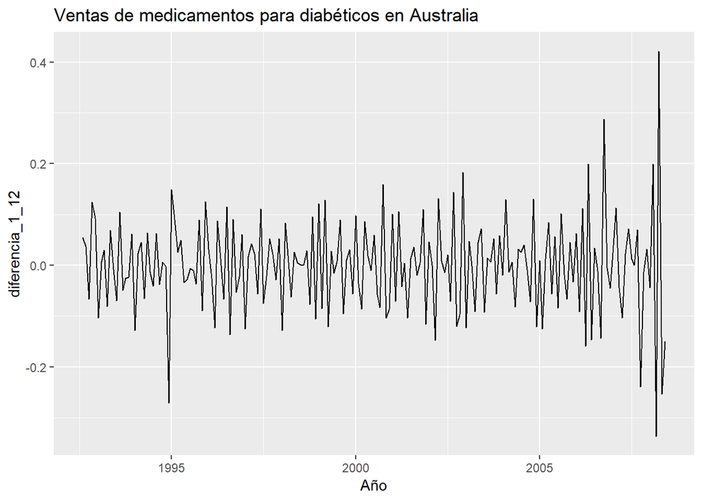

```r
diferencia_1 <- diff(log(a10),1)
diferencia_1_12 <-  diff(diferencia_1,lag=12)

autoplot(diferencia_1_12) +  ggtitle("Ventas de medicamentos para diabéticos en Australia")  + xlab("Año")
```

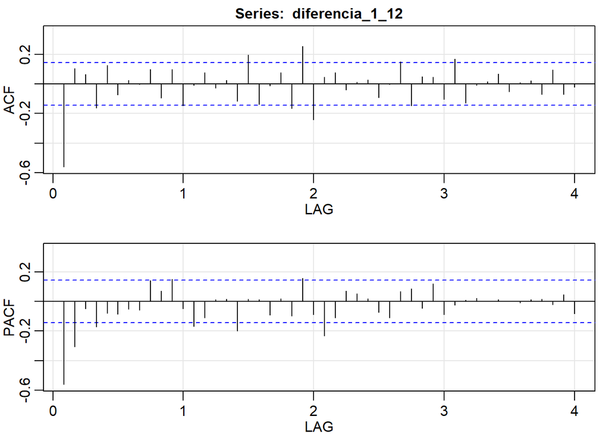

```
##         ACF  PACF
##  [1,] -0.56 -0.56
##  [2,]  0.11 -0.31
##  [3,]  0.06 -0.05
##  [4,] -0.16 -0.17
##  [5,]  0.13 -0.08
##  [6,] -0.07 -0.08
##  [7,]  0.02 -0.05
##  [8,]  0.00 -0.06
##  [9,]  0.10  0.14
## [10,] -0.10  0.07
## [11,]  0.10  0.15
## [12,] -0.15 -0.05
## [13,] -0.01 -0.17
## [14,]  0.08 -0.11
```

[output cut: 34 more lines]

```r
acf2(diferencia_1_12)
```

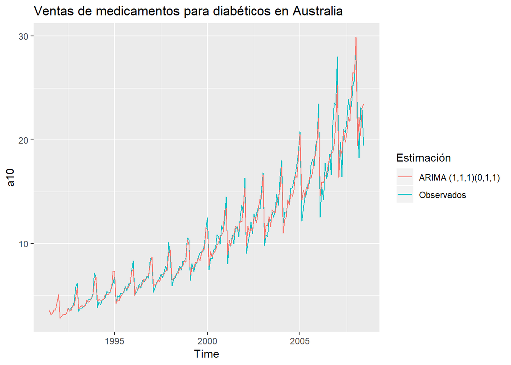

```r
mod3 <- Arima(a10, order=c(1,1,1), seasonal=c(0,1,1))
#mod1 <- sarima(a10,p=1,d=1,q=1,P=0,D=1,Q=1,S=12)

autoplot(a10, series="Observados")  +
  autolayer(fitted(mod3 ), series="ARIMA (1,1,1)(0,1,1)")+
  ggtitle("Ventas de medicamentos para diabéticos en Australia") +
  guides(colour=guide_legend(title="Estimación"))
```

# Diagnósticos del ARIMA

## unemp

```r
mod1 <-sarima(unemp,p=2,d=1,q=0,P=0,D=1,Q=1,S=12)
```

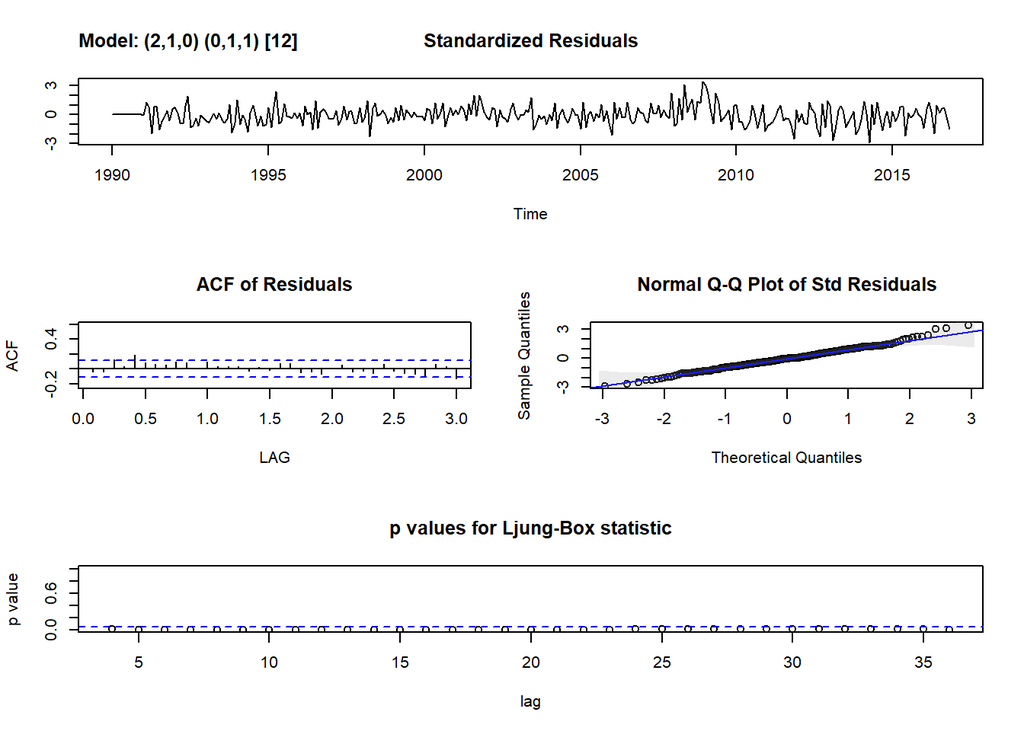

## birth

```r
mod2 <- sarima(birth,p=1,d=1,q=1,P=0,D=1,Q=1,S=12)
```

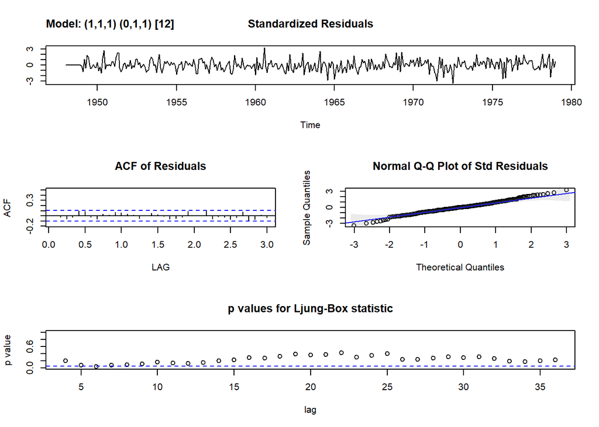

## a10

```r
mod1 <- sarima(a10,p=1,d=1,q=1,P=0,D=1,Q=1,S=12)
```

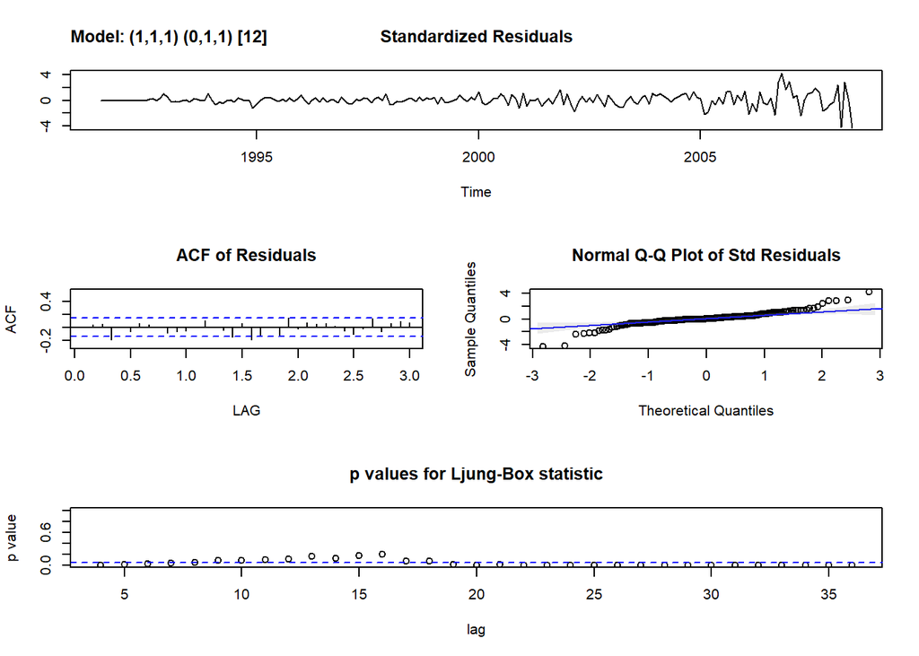

# Pronóstico del ARIMA

## unemp

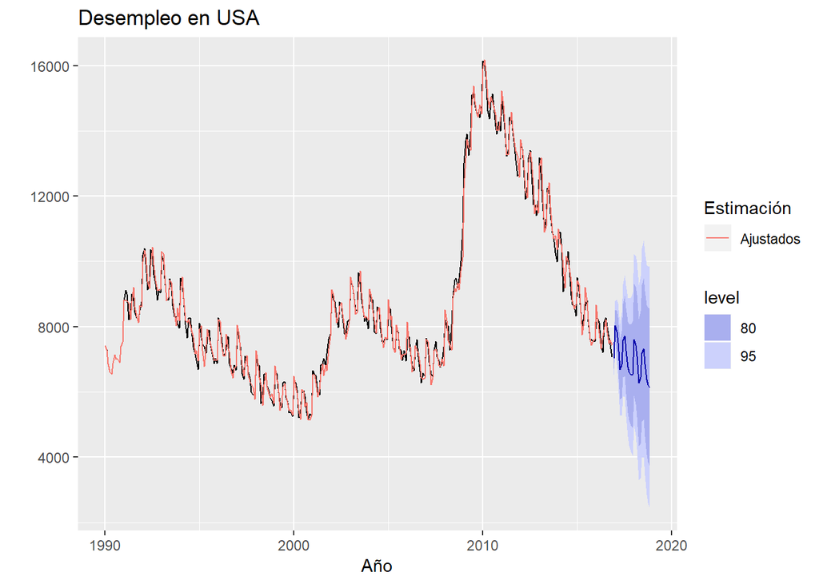

```r
mod1.1 <- Arima(unemp, order=c(2,1,0), seasonal=c(0,1,1))


mod1.1 %>% forecast(h=24) %>%
  autoplot() +
  autolayer(fitted(mod1.1), series="Ajustados") +
  ylab("") + xlab("Año") +
  ggtitle("Desempleo en USA") +
  guides(colour=guide_legend(title="Estimación"))
```

## birth

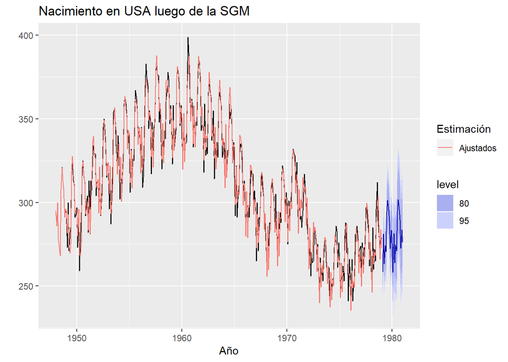

```r
mod2 <- Arima(birth, order=c(1,1,1), seasonal=c(0,1,1))

mod2 %>% forecast(h=24) %>%
  autoplot() +
  autolayer(fitted(mod2), series="Ajustados") +
  ylab("") + xlab("Año") +
  ggtitle("Nacimiento en USA luego de la SGM") +
  guides(colour=guide_legend(title="Estimación"))
```

## a10

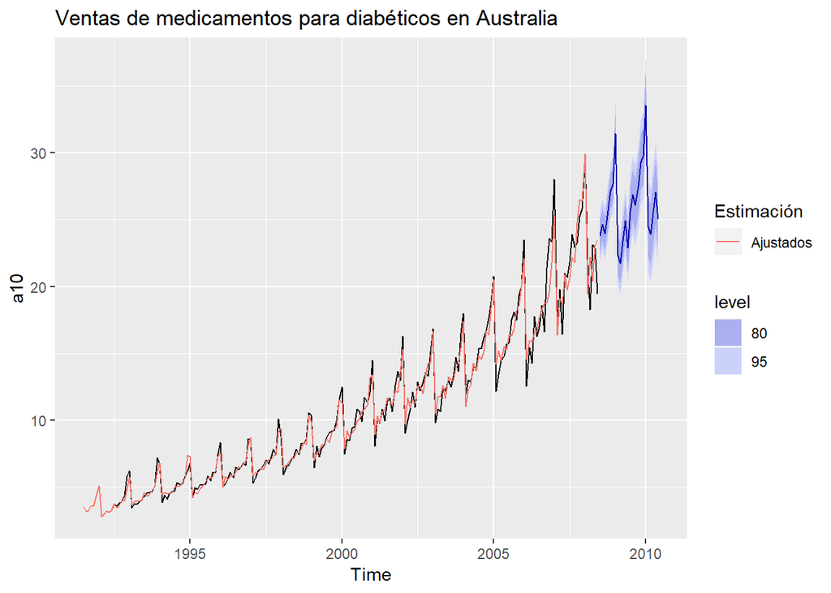

```r
mod3 <- Arima(a10, order=c(1,1,1), seasonal=c(0,1,1))

mod3 %>% forecast(h=24) %>%
  autoplot() +
  autolayer(fitted(mod3 ), series="Ajustados")+
  ggtitle("Ventas de medicamentos para diabéticos en Australia") +
  guides(colour=guide_legend(title="Estimación"))
```

# Estimación de la función auto.arima()

## unemp

```r
mod1.1 <- Arima(unemp, order=c(2,1,0), seasonal=c(0,1,1))
mod1.2 <- auto.arima(unemp)

summary(mod1.1)
```

```
## Series: unemp
## ARIMA(2,1,0)(0,1,1)[12]
##
## Coefficients:
##          ar1     ar2     sma1
##       0.0946  0.2081  -0.8512
## s.e.  0.0556  0.0556   0.0423
##
## sigma^2 estimated as 66176:  log likelihood=-2166.66
## AIC=4341.31   AICc=4341.44   BIC=4356.26
##
## Training set error measures:
##                     ME     RMSE      MAE        MPE     MAPE      MASE
## Training set -15.12281 250.7945 194.7522 -0.1669265 2.269629 0.1870934
##                     ACF1
## Training set -0.04149775
```

```r
summary(mod1.2)
```

```
## Series: unemp
## ARIMA(2,0,2)(1,1,2)[12]
##
## Coefficients:
##          ar1      ar2      ma1     ma2    sar1     sma1     sma2
##       1.9434  -0.9465  -0.9730  0.1391  0.0602  -0.8595  -0.0001
## s.e.  0.0290   0.0288   0.0647  0.0597  0.5469   0.5447   0.4561
##
## sigma^2 estimated as 60422:  log likelihood=-2158.67
## AIC=4333.34   AICc=4333.82   BIC=4363.26
##
## Training set error measures:
##                    ME     RMSE      MAE        MPE     MAPE     MASE
## Training set 8.938405 238.4701 186.4222 0.05463886 2.173326 0.179091
##                     ACF1
## Training set 0.007368937
```

```r
a<- round(accuracy(mod1.1),2)
b<- round(accuracy(mod1.2),2)

c<-rbind(a,b)
rownames(c)  <- c("ARIMA", "auto.arima")
c
```

```
##                ME   RMSE    MAE   MPE MAPE MASE  ACF1
## ARIMA      -15.12 250.79 194.75 -0.17 2.27 0.19 -0.04
## auto.arima   8.94 238.47 186.42  0.05 2.17 0.18  0.01
```

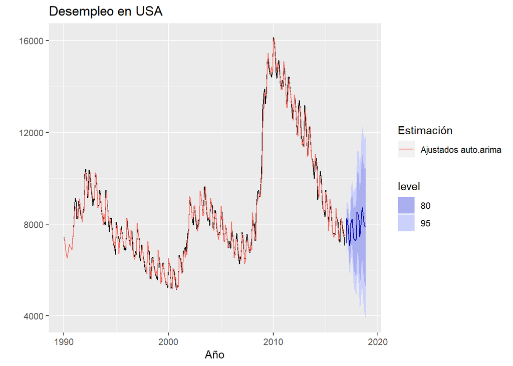

```r
mod1.2 %>% forecast(h=24) %>%
  autoplot() +
  autolayer(fitted(mod1.2), series="Ajustados auto.arima") +
  ylab("") + xlab("Año") +
  ggtitle("Desempleo en USA") +
  guides(colour=guide_legend(title="Estimación"))
```

## birth

```r
mod2.1 <- Arima(birth, order=c(1,1,1), seasonal=c(0,1,1))
mod2.2 <- auto.arima(birth)

summary(mod2.1)
```

```
## Series: birth
## ARIMA(1,1,1)(0,1,1)[12]
##
## Coefficients:
##          ar1      ma1     sma1
##       0.3038  -0.7006  -0.8000
## s.e.  0.0865   0.0604   0.0441
##
## sigma^2 estimated as 46.3:  log likelihood=-1205.93
## AIC=2419.85   AICc=2419.97   BIC=2435.4
##
## Training set error measures:
##                       ME     RMSE      MAE         MPE     MAPE      MASE
## Training set -0.04563711 6.657134 5.079695 -0.01582804 1.664997 0.5177216
##                    ACF1
## Training set 0.01149696
```

```r
summary(mod2.1)
```

```
## Series: birth
## ARIMA(1,1,1)(0,1,1)[12]
##
## Coefficients:
##          ar1      ma1     sma1
##       0.3038  -0.7006  -0.8000
## s.e.  0.0865   0.0604   0.0441
##
## sigma^2 estimated as 46.3:  log likelihood=-1205.93
## AIC=2419.85   AICc=2419.97   BIC=2435.4
##
## Training set error measures:
##                       ME     RMSE      MAE         MPE     MAPE      MASE
## Training set -0.04563711 6.657134 5.079695 -0.01582804 1.664997 0.5177216
##                    ACF1
## Training set 0.01149696
```

```r
a<- round(accuracy(mod2.1),2)
b<- round(accuracy(mod2.2),2)

c<-rbind(a,b)
rownames(c)  <- c("ARIMA", "auto.arima")
c
```

```
##               ME RMSE  MAE   MPE MAPE MASE ACF1
## ARIMA      -0.05 6.66 5.08 -0.02 1.66 0.52 0.01
## auto.arima -0.10 6.63 5.06 -0.03 1.66 0.52 0.01
```

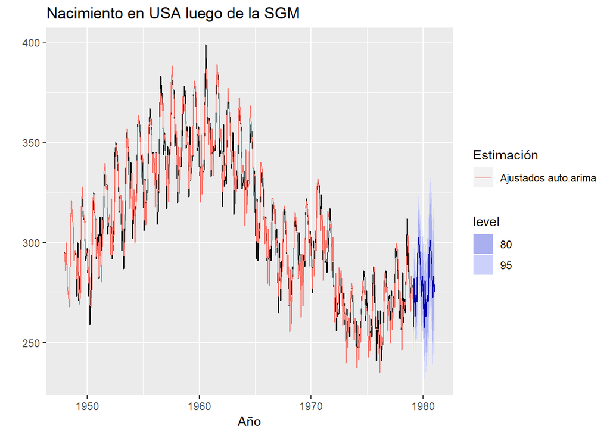

```r
mod2.2 %>% forecast(h=24) %>%
  autoplot() +
  autolayer(fitted(mod2.2), series="Ajustados auto.arima") +
  ylab("") + xlab("Año") +
  ggtitle("Nacimiento en USA luego de la SGM") +
  guides(colour=guide_legend(title="Estimación"))
```

## a10

```r
mod3.1 <- Arima(a10, order=c(1,1,1), seasonal=c(0,1,1))
mod3.2 <-  auto.arima(a10)

summary(mod3.1)
```

```
## Series: a10
## ARIMA(1,1,1)(0,1,1)[12]
##
## Coefficients:
##           ar1      ma1     sma1
##       -0.2504  -0.6674  -0.4725
## s.e.   0.1007   0.0870   0.0641
##
## sigma^2 estimated as 0.8756:  log likelihood=-258.82
## AIC=525.63   AICc=525.85   BIC=538.64
##
## Training set error measures:
##                      ME      RMSE       MAE        MPE     MAPE      MASE
## Training set 0.05924459 0.8982771 0.5761196 0.02969764 4.901351 0.4447873
##                     ACF1
## Training set -0.00487128
```

```r
summary(mod3.2)
```

```
## Series: a10
## ARIMA(1,1,1)(0,1,1)[12]
##
## Coefficients:
##           ar1      ma1     sma1
##       -0.2504  -0.6674  -0.4725
## s.e.   0.1007   0.0870   0.0641
##
## sigma^2 estimated as 0.8756:  log likelihood=-258.82
## AIC=525.63   AICc=525.85   BIC=538.64
##
## Training set error measures:
##                      ME      RMSE       MAE        MPE     MAPE      MASE
## Training set 0.05924459 0.8982771 0.5761196 0.02969764 4.901351 0.4447873
##                     ACF1
## Training set -0.00487128
```

```r
a<- round(accuracy(mod3.1),2)
b<- round(accuracy(mod3.2),2)

c<-rbind(a,b)
rownames(c)  <- c("ARIMA", "auto.arima")
c
```

```
##              ME RMSE  MAE  MPE MAPE MASE ACF1
## ARIMA      0.06  0.9 0.58 0.03  4.9 0.44    0
## auto.arima 0.06  0.9 0.58 0.03  4.9 0.44    0
```

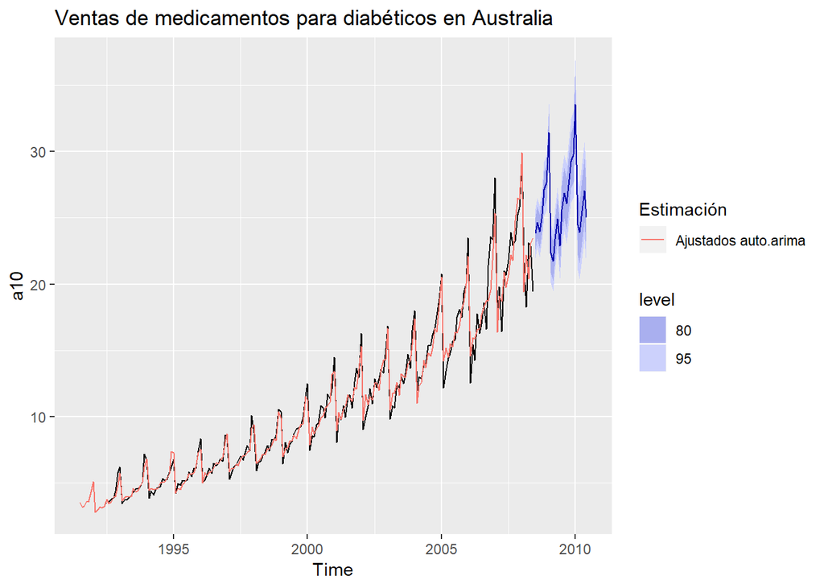

```r
mod3.2 %>% forecast(h=24) %>%
  autoplot() +
  autolayer(fitted(mod3.2), series="Ajustados auto.arima")+
  ggtitle("Ventas de medicamentos para diabéticos en Australia") +
  guides(colour=guide_legend(title="Estimación"))
```